# ML_Assignment 5

Jacob Joy

```r
library(factoextra)
library(dplyr)
library(dbscan)
library(fpc)
```

```r
library(ggplot2)
set.seed(123)
#laptop Data Import
#wines = read.csv("C:\\wine-clustering.csv")
#Desktop Data Import
wines = read.csv("F:\\wine-clustering.csv")
```

# Q1-A Explain how normalization and the number of clusters (k) can affect the clustering outcome?

When performing clustering the normalization of data as well as the number of clusters *k* is important in producing acurate outcomes. Clustering depends on the use of a distance metric commonly the euclidean distance, because of this if our data has different scales one variable could over take the others causing our model to not utilize all the relevant information. This leads to clusters that may not represent actual clusters and will be over taken by the largest valued variables. The number of clusters selected will also effect the outcome, accuracy, and meaningfulness of the results. If a small value of clusters *k* is used there may not be enough groups to sort the observations in a proper way, this can lead to lose of important patterns and clusters that should be separate will can end up being merged to fit the value of *k*. On the other hand if to high of a value of *k* is used there may be too many clusters to give any meaningful interpretations. A large number for *k* may also result in clusters that should not be split up being broken up into multiple clusters to satisfy our value for *k*. One final issue with a large value of *k* could mean clusters may be formed with too few observations making them not as meaningful.

# Q1-B Code

```r
#Check the structure of the data
str(wines)
```

```
## 'data.frame':    178 obs. of  13 variables:
##  $ Alcohol             : num  14.2 13.2 13.2 14.4 13.2 ...
##  $ Malic_Acid          : num  1.71 1.78 2.36 1.95 2.59 1.76 1.87 2.15 1.64 1.35 ...
##  $ Ash                 : num  2.43 2.14 2.67 2.5 2.87 2.45 2.45 2.61 2.17 2.27 ...
##  $ Ash_Alcanity        : num  15.6 11.2 18.6 16.8 21 15.2 14.6 17.6 14 16 ...
##  $ Magnesium           : int  127 100 101 113 118 112 96 121 97 98 ...
##  $ Total_Phenols       : num  2.8 2.65 2.8 3.85 2.8 3.27 2.5 2.6 2.8 2.98 ...
##  $ Flavanoids          : num  3.06 2.76 3.24 3.49 2.69 3.39 2.52 2.51 2.98 3.15 ...
##  $ Nonflavanoid_Phenols: num  0.28 0.26 0.3 0.24 0.39 0.34 0.3 0.31 0.29 0.22 ...
##  $ Proanthocyanins     : num  2.29 1.28 2.81 2.18 1.82 1.97 1.98 1.25 1.98 1.85 ...
##  $ Color_Intensity     : num  5.64 4.38 5.68 7.8 4.32 6.75 5.25 5.05 5.2 7.22 ...
##  $ Hue                 : num  1.04 1.05 1.03 0.86 1.04 1.05 1.02 1.06 1.08 1.01 ...
##  $ OD280               : num  3.92 3.4 3.17 3.45 2.93 2.85 3.58 3.58 2.85 3.55 ...
##  $ Proline             : int  1065 1050 1185 1480 735 1450 1290 1295 1045 1045 ...
```

```r
#summary check
summary(wines)
```

```
##     Alcohol        Malic_Acid         Ash         Ash_Alcanity
##  Min.   :11.03   Min.   :0.740   Min.   :1.360   Min.   :10.60
##  1st Qu.:12.36   1st Qu.:1.603   1st Qu.:2.210   1st Qu.:17.20
##  Median :13.05   Median :1.865   Median :2.360   Median :19.50
##  Mean   :13.00   Mean   :2.336   Mean   :2.367   Mean   :19.49
##  3rd Qu.:13.68   3rd Qu.:3.083   3rd Qu.:2.558   3rd Qu.:21.50
##  Max.   :14.83   Max.   :5.800   Max.   :3.230   Max.   :30.00
##    Magnesium      Total_Phenols     Flavanoids    Nonflavanoid_Phenols
##  Min.   : 70.00   Min.   :0.980   Min.   :0.340   Min.   :0.1300
##  1st Qu.: 88.00   1st Qu.:1.742   1st Qu.:1.205   1st Qu.:0.2700
##  Median : 98.00   Median :2.355   Median :2.135   Median :0.3400
##  Mean   : 99.74   Mean   :2.295   Mean   :2.029   Mean   :0.3619
##  3rd Qu.:107.00   3rd Qu.:2.800   3rd Qu.:2.875   3rd Qu.:0.4375
##  Max.   :162.00   Max.   :3.880   Max.   :5.080   Max.   :0.6600
##  Proanthocyanins Color_Intensity       Hue             OD280
##  Min.   :0.410   Min.   : 1.280   Min.   :0.4800   Min.   :1.270
##  1st Qu.:1.250   1st Qu.: 3.220   1st Qu.:0.7825   1st Qu.:1.938
##  Median :1.555   Median : 4.690   Median :0.9650   Median :2.780
##  Mean   :1.591   Mean   : 5.058   Mean   :0.9574   Mean   :2.612
##  3rd Qu.:1.950   3rd Qu.: 6.200   3rd Qu.:1.1200   3rd Qu.:3.170
##  Max.   :3.580   Max.   :13.000   Max.   :1.7100   Max.   :4.000
##     Proline
##  Min.   : 278.0
##  1st Qu.: 500.5
##  Median : 673.5
##  Mean   : 746.9
##  3rd Qu.: 985.0
##  Max.   :1680.0
```

```r
#Check for missing values
colMeans(is.na(wines))
```

```
##              Alcohol           Malic_Acid                  Ash
##                    0                    0                    0
##         Ash_Alcanity            Magnesium        Total_Phenols
##                    0                    0                    0
##           Flavanoids Nonflavanoid_Phenols      Proanthocyanins
##                    0                    0                    0
##      Color_Intensity                  Hue                OD280
##                    0                    0                    0
##              Proline
##                    0
```

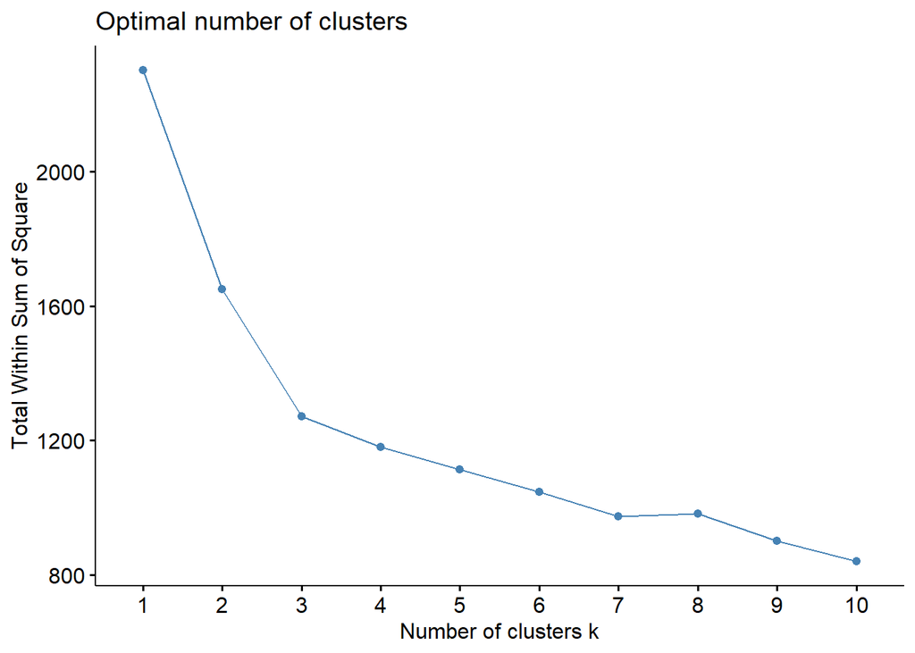

```r
#Normalize data
wines.norm = scale(wines)

#finding a optimal value for k using Elbow Method
fviz_nbclust(wines.norm, kmeans, method = "wss")
```

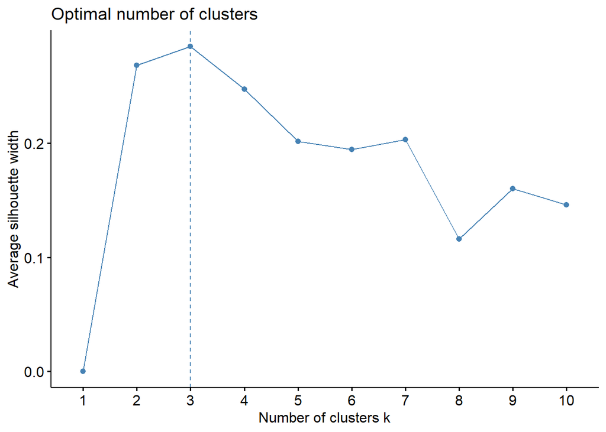

```r
#finding optimal value for k using Silhouette
fviz_nbclust(wines.norm, kmeans, method = "silhouette")
```

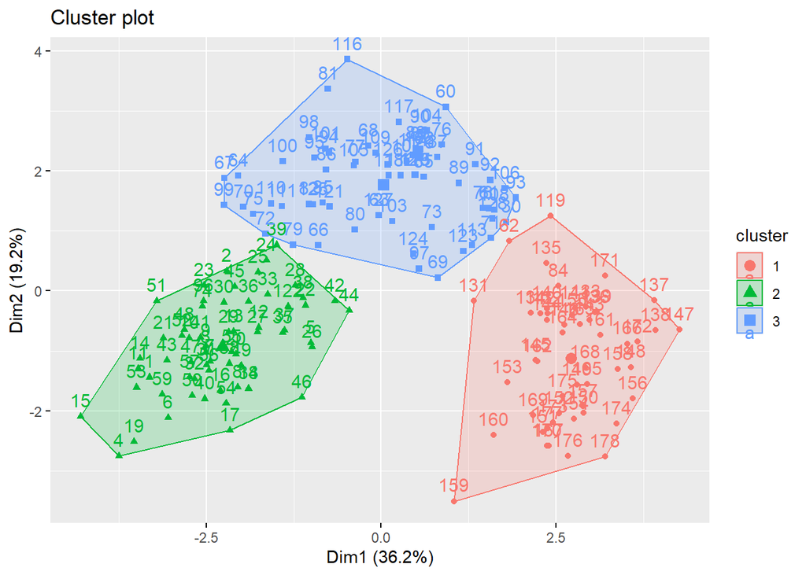

```r
#Performing K means with a k value of 3 based on the elbow point and the peak Silhouette
k3 = kmeans(wines.norm, centers = 3, nstart = 25)

#Plot of clusters
fviz_cluster(k3, data = wines.norm)
```

```r
#Centers
k3$centers
```

```
##      Alcohol Malic_Acid        Ash Ash_Alcanity   Magnesium Total_Phenols
## 1  0.1644436  0.8690954  0.1863726    0.5228924 -0.07526047   -0.97657548
## 2  0.8328826 -0.3029551  0.3636801   -0.6084749  0.57596208    0.88274724
## 3 -0.9234669 -0.3929331 -0.4931257    0.1701220 -0.49032869   -0.07576891
##    Flavanoids Nonflavanoid_Phenols Proanthocyanins Color_Intensity        Hue
## 1 -1.21182921           0.72402116     -0.77751312       0.9388902 -1.1615122
## 2  0.97506900          -0.56050853      0.57865427       0.1705823  0.4726504
## 3  0.02075402          -0.03343924      0.05810161      -0.8993770  0.4605046
##        OD280    Proline
## 1 -1.2887761 -0.4059428
## 2  0.7770551  1.1220202
## 3  0.2700025 -0.7517257
```

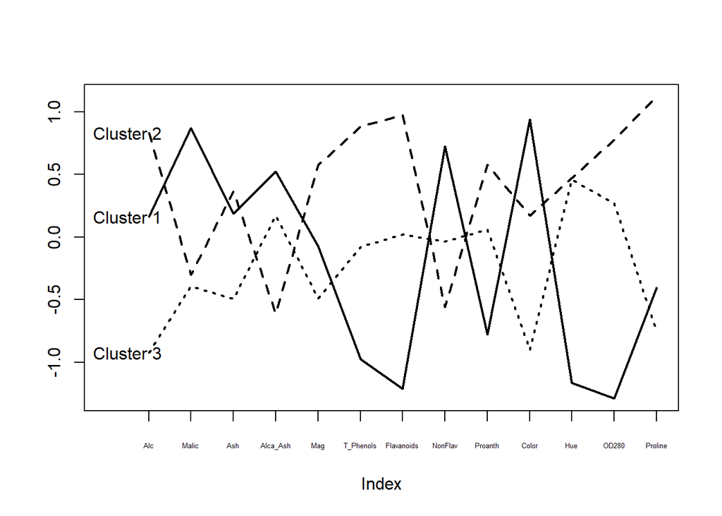

```r
#Setting up and plotting centroids
mincenter = min(k3$centers)
maxcenter = max(k3$centers)
plot(c(0), xaxt = 'n', ylab = "", type ="l", ylim = c(mincenter, maxcenter), xlim = c(0, 13))
axis(1, at = c(1:13), xpd = TRUE, labels = c("Alc","Malic","Ash","Alca_Ash","Mag","T_Phenols","Flavanoids","NonFlav", "Proanth", "Color", "Hue", "OD280", "Proline"), cex.axis = 0.4)

for(i in c(1:3))
  lines(k3$centers[i,], lty = i, lwd = 2)

text(x = 0.5, y = k3$centers[, 1], labels = paste("Cluster", c(1:3)))
```

```r
#size
k3$size
```

```
## [1] 51 62 65
```

```r
#withinss
k3$withinss
```

```
## [1] 326.3537 385.6983 558.6971
```